# in

### Random Forest (with class_weights)

```python
## Building the model
rf_balanced = RandomForestClassifier(class_weight="balanced", random_state=42)

## Complete the code to fit the model on X_train and y_train
rf_balanced.fit(X_train, y_train)
```

```
RandomForestClassifier(class_weight='balanced', random_state=42)
```

**Confusion Matrix**

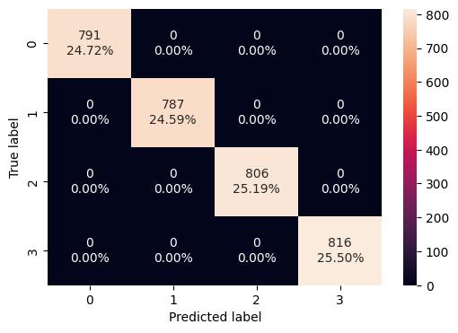

```python
## To get the confusion matrix on X_train and y_train
confusion_matrix_sklearn(rf_balanced, X_train, y_train)
```

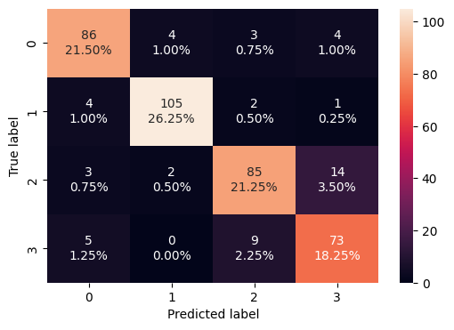

```python
## Write the code to get the confusion matrix for X_valid and y_valid
confusion_matrix_sklearn(rf_balanced, X_valid, y_valid)
```

```python
## Predicting on train data
y_pred_train = rf_balanced.predict(X_train)

## Complete the code to predict the model on X_valid
y_pred_valid = rf_balanced.predict(X_valid)
```

**Classification report**

```python
## Classification report for train data
print(classification_report(y_train, y_pred_train))
```

```
              precision    recall  f1-score   support

           0       1.00      1.00      1.00       791
           1       1.00      1.00      1.00       787
           2       1.00      1.00      1.00       806
           3       1.00      1.00      1.00       816

    accuracy                           1.00      3200
   macro avg       1.00      1.00      1.00      3200
weighted avg       1.00      1.00      1.00      3200
```

```python
## Write the code to get the classification report for validation data
print(classification_report(y_valid, y_pred_valid))
```

```
              precision    recall  f1-score   support

           0       0.88      0.89      0.88        97
           1       0.95      0.94      0.94       112
           2       0.86      0.82      0.84       104
           3       0.79      0.84      0.82        87

    accuracy                           0.87       400
   macro avg       0.87      0.87      0.87       400
weighted avg       0.87      0.87      0.87       400
```

```python
## Storing the metrics
rf_bal_train_perf = model_performance_classification_sklearn(
    rf_balanced, X_train, y_train
)
```

```python
## Complete the code to store the metrics of validation data
rf_bal_valid_perf = model_performance_classification_sklearn(rf_balanced, X_valid, y_valid)
```

### Random Forest (with hyperparamter tuning)

```python
## Building the model
rf_tuned = RandomForestClassifier(class_weight="balanced", random_state=42)

## Defining the hyperparameter grid for tuning
parameters = {
    "max_depth": [6, 9],
    "max_features": ["sqrt", 0.5],
    "min_samples_split": [5],
    "n_estimators": [50, 100],
}

## Defining the type of scoring used to compare parameter combinations
## We need to specify the mechanism of averaging as we have more than 2 target classes
scorer = make_scorer(recall_score, average='weighted')

## Running the grid search
grid_obj = GridSearchCV(rf_tuned, parameters, scoring=scorer, cv=3, n_jobs=-1)

## Complete the code to fit the model on X_train and y_train
grid_obj = grid_obj.fit(X_train, y_train)
```

```python
print(grid_obj.best_params_)
```

```
{'max_depth': 9, 'max_features': 'sqrt', 'min_samples_split': 5, 'n_estimators': 100}
```

The grid search picked max_depth=9, max_features='sqrt', min_samples_split=5, and n_estimators=100 as the best combination. Both the max_depth and the number of trees landed on the highest values I tested, which makes me think the model could probably keep improving if I let trees go deeper or used more of them. My grid was running slow so I did not test them. Limiting max_depth=9 keeps the trees from growing all the way down like the base model did, so the tuned model isn't memorizing the training set as much. The training accuracy drops compared to the base RF, but the validation accuracy stays about the same.

The class-weighted version barely changed anything compared to the base model. That makes sense because the dataset is perfectly balanced at 1000 articles per category, so class weights aren't really fixing any imbalance problem. All three Random Forest models end up pretty close to each other on the validation set, with the tuned one being slightly better at generalizing.

```python
## Creating a new model with the best combination of parameters
rf_tuned = grid_obj.best_estimator_

## Complte the code to fit the new model to X_train and y_train
rf_tuned.fit(X_train, y_train)
```

```
RandomForestClassifier(class_weight='balanced', max_depth=9,
                       min_samples_split=5, random_state=42)
```

**Confusion Matrix**

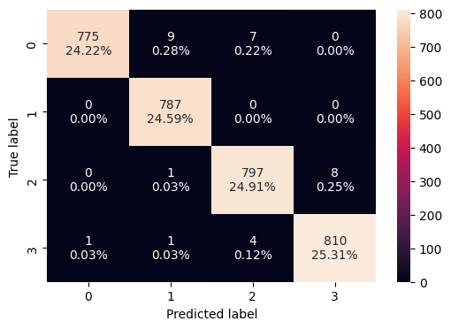

```python
## Write the code to get the classification report for train data
confusion_matrix_sklearn(rf_tuned, X_train, y_train)
```

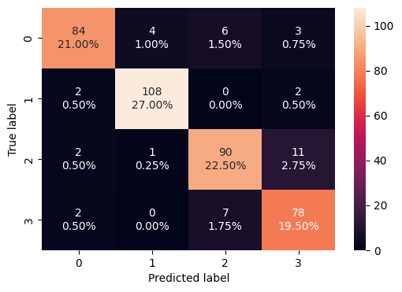

```python
## Write the code to get the classification report for validation data
confusion_matrix_sklearn(rf_tuned, X_valid, y_valid)
```

```python
## Complete the code to predict the model on train data
y_pred_train = rf_tuned.predict(X_train)

## Complete the code to predict the model on validation data
y_pred_valid = rf_tuned.predict(X_valid)
```

**Classification report**

```python
## Write the code to get the classification report for train data
print(classification_report(y_train, y_pred_train))
```

```
              precision    recall  f1-score   support

           0       1.00      0.98      0.99       791
           1       0.99      1.00      0.99       787
           2       0.99      0.99      0.99       806
           3       0.99      0.99      0.99       816

    accuracy                           0.99      3200
   macro avg       0.99      0.99      0.99      3200
weighted avg       0.99      0.99      0.99      3200
```

```python
## Write the code to get the classification report for validation data
print(classification_report(y_valid, y_pred_valid))
```

```
              precision    recall  f1-score   support

           0       0.93      0.87      0.90        97
           1       0.96      0.96      0.96       112
           2       0.87      0.87      0.87       104
           3       0.83      0.90      0.86        87

    accuracy                           0.90       400
   macro avg       0.90      0.90      0.90       400
weighted avg       0.90      0.90      0.90       400
```

```python
## Complete the code to store the metrics of train data
rf_tuned_train_perf = model_performance_classification_sklearn(rf_tuned, X_train, y_train)
```

```python
## Complete the code to store the metrics of validation data
rf_tuned_valid_perf = model_performance_classification_sklearn(rf_tuned, X_valid, y_valid)
```

## **Model Building - Transformer**

### Target Mapping

```python
class_map = {0:"World",1:"Sports",2:"Business",3:"Sci/Tech"}
```

```python
class_map
```

```
{0: 'World', 1: 'Sports', 2: 'Business', 3: 'Sci/Tech'}
```

```python
reverse_class_map = {}
for key,value in class_map.items():
    reverse_class_map[value]=key

reverse_class_map
```

```
{'World': 0, 'Sports': 1, 'Business': 2, 'Sci/Tech': 3}
```

### Defining the Tokenizer

```python
## Initializing a T5 tokenizer using the pre-trained model
tokenizer = T5Tokenizer.from_pretrained("google/flan-t5-large")
```

```json
{"model_id":"49ce69d741bc4bb39b835955cdcf39fc","version_major":2,"version_minor":0}
```

```json
{"model_id":"2b42de8aa61640229d9e3fc3194a3894","version_major":2,"version_minor":0}
```

```json
{"model_id":"2ad443bacbdd40ca8c12c91b5dcbe4d1","version_major":2,"version_minor":0}
```

```json
{"model_id":"bea02b75481540a9b496a4ef0b96f802","version_major":2,"version_minor":0}
```

### Defining the Model

```python
model = T5ForConditionalGeneration.from_pretrained(
    "google/flan-t5-large",
    device_map="auto",
    torch_dtype=torch.float16
)
```

```json
{"model_id":"f8b05c05e41249bd8b3d1875e53feab4","version_major":2,"version_minor":0}
```

```
The tied weights mapping and config for this model specifies to tie shared.weight to lm_head.weight, but both are present in the checkpoints, so we will NOT tie them. You should update the config with `tie_word_embeddings=False` to silence this warning
```

### Functions for making predictions

```python
## Defining a function to compute different metrics.

def model_performance_classification(pred, target):
    """
    Function to compute different metrics to check classification model performance

    pred : prediction of the target variable.
    target: dependent variable
    """


    acc = accuracy_score(target, pred)  # to compute Accuracy
    recall = recall_score(target, pred,average="weighted")  # to compute Recall
    precision = precision_score(target, pred,average="weighted")  # to compute Precision
    f1 = f1_score(target, pred,average="weighted")  # to compute F1-score

    # creating a dataframe of metrics
    df_perf = pd.DataFrame(
        {"Accuracy": acc, "Recall": recall, "Precision": precision, "F1": f1,},
        index=[0],
    )

    return df_perf
```

```python
## Creating a function to plot the confusion matrix
def plot_confusion_matrix(actual, predicted):
    cm = confusion_matrix(actual, predicted)

    plt.figure(figsize = (5, 4))
    label_list = ['World','Sports','Business','Sci/Tech']
    sns.heatmap(cm, annot = True,  fmt = '.0f', xticklabels = label_list, yticklabels = label_list)
    plt.ylabel('Actual')
    plt.xlabel('Predicted')
    plt.show()
```

```python
# defining a function to generate, process, and return a response
def generate_response(prompt):
    # uncomment and use the following line in case GPU is not available
    # input_ids = tokenizer(prompt, return_tensors="pt").input_ids    ### using the tokenizer to create tokens in tensor format from an input

    # uncomment and use the following line in case GPU is available
    input_ids = tokenizer(prompt, return_tensors="pt").input_ids.to("cuda")    ### using the tokenizer to create tokens in tensor format from an input

    outputs = model.generate(input_ids, max_length=16, do_sample=True, temperature=0.001)    ### generating the model output in tensor format
    return tokenizer.decode(outputs[0])[6:-4]    ### using the tokenizer to decode the model output, and then return it
```

### Base Prompt for Prediction

```python
## Selecting and assigning specific columns
X_train = data.iloc[y_train.index]["Article"]
X_valid = data.iloc[y_valid.index]["Article"]
X_test = data.iloc[y_test.index]["Article"]
```

```python
## Defining a prompt which tells the model what to do
sys_prompt = """
    Classify the news article below into one of the following categories: World, Sports, Business, Sci/Tech.
    Respond with only the category name and nothing else.
"""

## Predicting the category using the model by incorporating the system prompt and the provided review text

pred_sent = generate_response(
    """
        {}
        news article: '{}'
    """.format(sys_prompt, X_train.iloc[4])
)

print(pred_sent)
```

```
World
```

```python
## Defining a function to generate a sentiment prediction
def predict_category(news_article):
    pred = generate_response(
        """
            {}
            news article: '{}'
        """.format(sys_prompt,news_article)
    )

    if "Sports" in pred:
       pred="Sports"
    elif "Business" in pred:
       pred="Business"
    elif "World" in pred:
       pred="World"
    else:
      pred="Sci/Tech"

    return reverse_class_map[pred]
```

```python
## Applying predict_category function on the train data
X_train_sample = X_train.sample(500, random_state=42)
y_train_sample = y_train.loc[X_train_sample.index]
y_pred_train_flan = X_train_sample.apply(predict_category)
```

```python
## Applying predict_category function on the validation data
y_pred_valid_flan = X_valid.apply(predict_category)
```

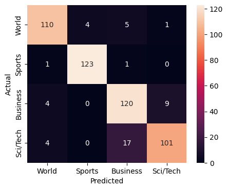

```python
## Plotting the confusion matrix
plot_confusion_matrix(y_train_sample, y_pred_train_flan)
```

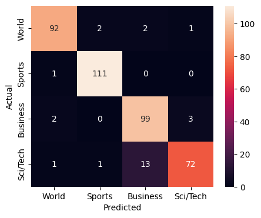

```python
## Complete the code to get the confusion matrix for validation data
plot_confusion_matrix(y_valid, y_pred_valid_flan)
```

```python
## Getting the classification report for train data
print(classification_report(y_train_sample, y_pred_train_flan))
```

```
              precision    recall  f1-score   support

           0       0.92      0.92      0.92       120
           1       0.97      0.98      0.98       125
           2       0.84      0.90      0.87       133
           3       0.91      0.83      0.87       122

    accuracy                           0.91       500
   macro avg       0.91      0.91      0.91       500
weighted avg       0.91      0.91      0.91       500
```

```python
## Complete the code to get the classification report for validation data
print(classification_report(y_valid, y_pred_valid_flan))
```

```
              precision    recall  f1-score   support

           0       0.96      0.95      0.95        97
           1       0.97      0.99      0.98       112
           2       0.87      0.95      0.91       104
           3       0.95      0.83      0.88        87

    accuracy                           0.94       400
   macro avg       0.94      0.93      0.93       400
weighted avg       0.94      0.94      0.93       400
```

```python
## Storing the metrics
flan_train_base = model_performance_classification(y_pred_train_flan, y_train_sample)
flan_valid_base = model_performance_classification(y_pred_valid_flan, y_valid)
```

### Improved Prompt for Prediction

```python
# defining a prompt which tells the model what to do
sys_prompt = """
    You are a news categorization assistant. Read the news article and classify it into exactly ONE of these four categories:

    - World: international politics, foreign affairs, war, diplomacy, national governments
    - Sports: athletes, games, tournaments, leagues, scores, championships
    - Business: companies, markets, economy, finance, trade, stocks, earnings
    - Sci/Tech: science, technology, research, computers, internet, space, medicine

    Respond with only the single category name (World, Sports, Business, or Sci/Tech). Do not explain your reasoning.
"""

pred_sent = generate_response(
    """
        {}
        news article: '{}'
    """.format(sys_prompt, X_train.iloc[4])
)

print(pred_sent)
```

```
World
```

```python
## Applying predict_category function on the train data
y_pred_train_flan_imp = X_train_sample.apply(predict_category)
```

```python
## Applying predict_category function on the validation data
y_pred_valid_flan_imp = X_valid.apply(predict_category)
```

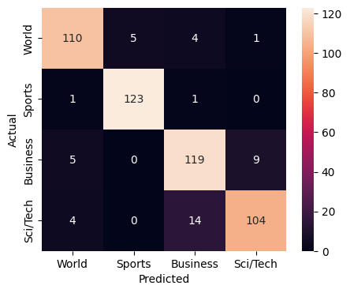

```python
## Plotting the confusion matrix for train data
plot_confusion_matrix(y_train_sample, y_pred_train_flan_imp)
```

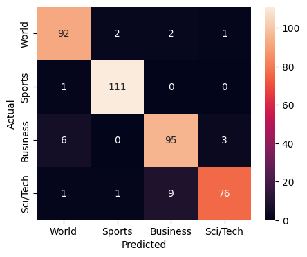

```python
## Complete the codet to get the confusion matrix for validation data
plot_confusion_matrix(y_valid, y_pred_valid_flan_imp)
```

```python
## Getting the classification report for train data
print(classification_report(y_train_sample, y_pred_train_flan_imp))
```

```
              precision    recall  f1-score   support

           0       0.92      0.92      0.92       120
           1       0.96      0.98      0.97       125
           2       0.86      0.89      0.88       133
           3       0.91      0.85      0.88       122

    accuracy                           0.91       500
   macro avg       0.91      0.91      0.91       500
weighted avg       0.91      0.91      0.91       500
```

```python
## Complete the code to get the classification report for validation data
print(classification_report(y_valid, y_pred_valid_flan_imp))
```

```
              precision    recall  f1-score   support

           0       0.92      0.95      0.93        97
           1       0.97      0.99      0.98       112
           2       0.90      0.91      0.90       104
           3       0.95      0.87      0.91        87

    accuracy                           0.94       400
   macro avg       0.93      0.93      0.93       400
weighted avg       0.94      0.94      0.93       400
```

```python
## Storing the metrics
flan_train_imp = model_performance_classification(y_pred_train_flan_imp, y_train_sample)
flan_valid_imp = model_performance_classification(y_pred_valid_flan_imp, y_valid)
```